# S1.5b: con i tipi cellulari nei preset, il simulatore dà a ogni tipo la taglia di nucleo che ha nei tessuti veri?

geo_spatialtrans, report di step (protocollo v2)

Published

October 23, 2026

# In breve

## In breve: con i tipi cellulari, il simulatore dà a ogni tipo la taglia di nucleo che ha nei tessuti veri?

**A cosa serviva.** Fino a oggi il simulatore metteva un solo tipo di cellula per tessuto, con una sola taglia di nucleo. Qui abbiamo portato nei sei tessuti i tipi cellulari, con le quote misurate sui nuclei veri, e dato a ogni gruppo di tipi simili il suo modello di taglia del nucleo. Poi abbiamo fatto girare il simulatore sulle stesse 30 aree di tessuto vero dei passi precedenti (5 per tessuto, 10 ripetizioni ciascuna) e controllato la taglia tipo per tipo.

**Cosa abbiamo trovato.**

1. **Con i tipi la taglia del nucleo torna in 14 tipi su 17 (senza tipi in 9), e la coda di cellule senza citoplasma del tumore del colon è sparita.**
   - Ha vinto, con la regola scritta prima, la versione che ricentra ogni tipo. Nel territorio tipico del simulatore, ogni tipo riceve la taglia che ha nel suo territorio tipico vero. La vittoria è stata di misura: le due versioni hanno pareggiato e ha deciso lo stroma, che nell’altra versione esce appena dall’intervallo.
   - Nel tumore del colon le cellule quasi senza citoplasma scendono da 3,6 a 2,2 su 100, sotto il massimo delle aree vere (2,9): era il difetto che i tipi dovevano correggere.
   - Fuori restano gli astrociti del cervello (34 µm² contro 48,5-54 nelle aree vere), come previsto: condividono il modello della glia, che ha nuclei più piccoli. Al limite basso stanno l’epitelio del tumore e i neuroni. Per i neuroni il motivo è che il modello riproduce la media geometrica dei nuclei veri, più bassa della mediana.
   - Nel linfonodo B e T condividono lo stesso modello di taglia, come avevi deciso. Escono con nuclei del 6 % più grandi per i B (16,9 contro 15,9 µm²) perché nei tessuti veri hanno territori più grandi; così tornano tutti e due con le aree vere.
2. **Il revisore del codice ha trovato un errore nel modo in cui il simulatore piazzava i tipi; l’abbiamo corretto e rifatto tutto.**
   - I tipi venivano piazzati uno dopo l’altro e l’ultimo riceveva territori più piccoli: del 10 % per le cellule mieloidi del linfonodo. Ora tutte le cellule si piazzano insieme e il tipo si assegna dopo, a caso.
   - Con la correzione sono cambiati 6 esiti su 165 e nessuna conclusione. I risultati di prima sono conservati per il confronto.
3. **Nel cervello di topo le due taglie ci sono (i nuclei dei neuroni sono 3,5 volte quelli della glia, come nelle aree vere), ma la valle fra le due taglie non torna.**
   - Il modello della glia è troppo disperso. Una parte viene da oggetti minuscoli (4-8 µm²) che Cellpose trova soprattutto in un’area con sostanza bianca, etichettati come oligodendrociti: senza di loro la dispersione della glia scende di quasi un quinto, ma la valle non torna lo stesso.
   - Non sappiamo se siano nuclei veri o frammenti: in quell’area non abbiamo conteggi fatti a mano.
4. **I tipi non correggono lo spazio attorno al nucleo: il rapporto fra nucleo e territorio sbaglia in 11 tipi su 17, come previsto.**
   - Nel simulatore il territorio non dipende dal tipo; nei tessuti veri sì. I fibroblasti hanno territori grandi, l’epitelio piccoli, le cellule immunitarie del cuore stanno vicino ad altre cellule (8,8 µm dal vicino contro 14,5 simulati).
   - È un compito della disposizione dei centri delle cellule, non del modello di taglia.
5. **Nel cervello i nuclei che Cellpose perde non sono soprattutto glia, almeno nelle tue finestre: la quota di neuroni del preset passa dal 65 al 70 %.**
   - Il metodo che dà un tipo ai nuclei persi indovina 9 casi su 10 sui nuclei trovati, ma scambia per neuroni una parte della glia vicina ai neuroni. Tenendone conto la quota sarebbe 66 %; nelle finestre di Federica i persi sono soprattutto cellule dei vasi, e con tutte e due le valutazioni la quota sarebbe 61 %.
   - Tutti questi valori stanno dentro la variabilità fra le aree vere (dal 53 al 76 % di neuroni) e non cambiano nessun risultato.

**Cosa devi decidere.** Nulla: le scelte del passo erano tutte scritte prima (regola della versione, gruppi di taglia, composizione del cervello, stroma misto) e sono state applicate come scritte.

**Comunque:**

- il simulatore usa da oggi i tipi cellulari in tutti e sei i tessuti, con la versione ricentrata; il preset a un tipo resta disponibile e riproduce esattamente i passi precedenti;
- quando lavoreremo sulla disposizione dei centri delle cellule, li faremo dipendere dal tipo (territori grandi per i fibroblasti, ghiandole di epitelio, cellule immunitarie raggruppate, neuroni più distanziati) e rimisureremo lo spazio attorno al nucleo per tipo;
- gli oggetti minuscoli del cervello andranno contati a mano nell’area con sostanza bianca, in un passo futuro sui dati veri; fino ad allora il modello della glia resta com’è;
- lo stroma del tumore resta provvisorio finché non sceglieremo aree di stroma puro.

Non c’è nulla da decidere: se non hai dubbi, lo step è chiuso.

# Decisioni e verifiche di Luca

- «Approvo così» (ok a previsioni, intervalli e regola dei bracci, 2026-10-22)
- D-1: «Dare un tipo ai persi dall’espressione (Recommended)»; D-2: «Preset misto, come misurato (Recommended)» (2026-10-22)

# Dubbi rinviati

| cosa | perché | cosa serve per chiuderlo | step destinatario | voce di BACKLOG |
| --- | --- | --- | --- | --- |
| Rapporto nucleo/territorio per tipo smentito in 11 tipi su 17 (P-7) e del tessuto in 3 (P-8); distanze dal vicino per tipo diverse dal reale (D-desc-1) | la semina è unica per regione: il territorio e la vicinanza non dipendono dal tipo | semina che dipende dal tipo (aggregazione, compartimenti, distanza minima per tipo), rimisurata con P-7, P-8 e D-desc-1 sulle stesse 300 unità | Step 1.5, semina eterogenea (con BL-143) | BL-153 |
| Oggetti di 4-8 µm² nel cervello (7.8 % dei nuclei di riferimento, 22.6 % nella ROI r1 con sostanza bianca) gonfiano la dispersione della glia; la valle fra le due taglie non torna (P-4) | non sappiamo se siano nuclei veri: le finestre contate a mano non coprono la sostanza bianca | conteggio manuale in finestre di sostanza bianca della ROI r1; poi rifare il modello della glia ed eventualmente separare gli oligodendrociti | passo futuro sui dati veri (da assegnare) | BL-154 |
| Interfaccia dei tipi: semina cieca solo per i preset (cataloghi dell’utente in sequenza); C7 usa la densità del tipo puro (WARN in 2 unità del cervello); involucro degli script di S1.5 | non toccano i preset né il banco | semina cieca anche per i cataloghi con distanza minima comune; C7 sulla densità della miscela; involucro sostituito da argomenti espliciti | S1.6 (consolidamento) | BL-155, BL-156 |

# Cancelli

Pre-registrazione: commit `e0e015e` (cancelli e previsioni); ok di Luca il 2026-10-22 («Approvo così»), commit `9b92488`. Codice `fe432e8`; correzioni dopo la revisione `858dd1c`, predefiniti `946df1d`.

Cancelli (giro finale)

| id | controllo | esito |
| --- | --- | --- |
| G-1 | batteria di test (`R/testing/run_S1.5b.sh test`): test_S1.5b, test_S1.5, test_S1.4d, regressioni S1.1-S1.4, OKF | RISULTATO test_S1.5b: 22/22 PASS; GATE G-1 PASS |
| G-2 | mutanti (`run_S1.5b.sh mutants`) | mutanti rilevati 8/8 |
| G-3 | invarianti, riproducibilità, compatibilità sul banco (`tools/S1.5b_bench.R check`, md5) | units 900/900; no_error_C2_C3_C5_C9 900/900; n_failed_total 0/0; single_equals_S1.5_md5 300/300; rerun_identical 6/6; single_rerun_after_default_switch 6/6; md5 dei dati 101/101 |
| G-4 | calibrazione ricalcolata in R (`tools/S1.5b_calcheck.R`) | 12/12 confronti applicabili entro tolleranza |
| G-5 | ricalcolo indipendente della revisione avversariale | 3 583/3 583 confronti identici (secondo giro); 92 unità rigenerate, md5 identico |

# Previsioni

Unità indipendente: ROI (valore del ROI = media dei 10 semi); stima = media dei 5 ROI ± 2 errori standard. Intervalli = minimo e massimo fra le 5 ROI reali, dall’insieme di calibrazione (P-2, P-3, P-4, P-7) o da S1.5 (P-1, P-5, P-8). Il braccio vincente è «ricentrato»; gli altri due bracci si riportano accanto.

Regola del braccio: tipi confermati in P-2 (17 tipi principali), poi tessuti confermati in P-1

| arm | p2_confirmed | p2_n | p1_confirmed | winner | decided_by |
| --- | --- | --- | --- | --- | --- |
| group | 14 | 17 | 5 | recentred | P-1 |
| recentred | 14 | 17 | 6 | recentred | P-1 |
| single | 9 | 17 | 6 | recentred | P-1 |

Previsioni P-1…P-8: stima ± 2 errori standard ed esito, tre bracci

| id | tessuto | unità | intervallo | ricentrato | esito | gruppo | un tipo (nullo) |
| --- | --- | --- | --- | --- | --- | --- | --- |
| P-1 | intestino di topo | tessuto | 12.59-13.79 | 13.01 ± 0.02 | confermata | 13.21 ± 0.02 confermata | 13.2 ± 0.036 confermata |
| P-1 | tumore del colon | tessuto | 27.94-32.44 | 29.95 ± 0.097 | confermata | 31.61 ± 0.099 confermata | 31.09 ± 0.11 confermata |
| P-1 | stroma del tumore | tessuto | 27.79-33.79 | 30.59 ± 0.14 | confermata | 33.74 ± 0.099 indeterminata | 33.58 ± 0.07 confermata |
| P-1 | linfonodo | tessuto | 15.67-16.64 | 16.39 ± 0.012 | confermata | 16.32 ± 0.01 confermata | 16.32 ± 0.0078 confermata |
| P-1 | cervello di topo | tessuto | 56.88-119.2 | 81.28 ± 0.79 | confermata | 79.84 ± 0.78 confermata | 64.13 ± 1.2 confermata |
| P-1 | cuore | tessuto | 17.54-31.71 | 21.38 ± 0.13 | confermata | 21.84 ± 0.15 confermata | 21.87 ± 0.11 confermata |
| P-2 | intestino di topo | epiteliale | 13.57-15.06 | 14.02 ± 0.02 | confermata | 14.33 ± 0.02 confermata | 13.21 ± 0.05 smentita |
| P-2 | intestino di topo | stromale e muscolo liscio | 10.12-12.07 | 11.04 ± 0.061 | confermata | 11.04 ± 0.061 confermata | 13.2 ± 0.052 smentita |
| P-2 | intestino di topo | immunitario | 10.94-11.92 | 11.07 ± 0.048 | confermata | 11.06 ± 0.048 confermata | 13.17 ± 0.054 smentita |
| P-2 | tumore del colon | epiteliale | 31.84-33.86 | 31.87 ± 0.093 | indeterminata | 34.78 ± 0.098 smentita | 31.04 ± 0.092 smentita |
| P-2 | tumore del colon | fibroblasti | 20.86-34.5 | 24.14 ± 0.091 | confermata | 22.26 ± 0.084 confermata | 31.23 ± 0.14 confermata |
| P-2 | stroma del tumore | epiteliale | 27.72-43.15 | 29.23 ± 0.14 | confermata | 35.34 ± 0.17 confermata | 33.58 ± 0.12 confermata |
| P-2 | stroma del tumore | fibroblasti | 29.29-35.85 | 35.56 ± 0.27 | confermata | 35.4 ± 0.27 confermata | 33.61 ± 0.12 confermata |
| P-2 | stroma del tumore | endoteliale | 25.62-37.64 | 32.43 ± 0.48 | confermata | 35.51 ± 0.53 confermata | 33.43 ± 0.5 confermata |
| P-2 | stroma del tumore | immunitario | 23.19-30.41 | 25.63 ± 0.082 | confermata | 27.56 ± 0.088 confermata | 33.7 ± 0.4 smentita |
| P-2 | linfonodo | linfociti B | 16.26-17.24 | 16.85 ± 0.016 | confermata | 16.32 ± 0.015 confermata | 16.31 ± 0.0075 confermata |
| P-2 | linfonodo | linfociti T | 15.67-16.41 | 15.88 ± 0.0094 | confermata | 16.33 ± 0.0097 confermata | 16.32 ± 0.016 confermata |
| P-2 | cervello di topo | neuroni | 97.92-138.8 | 98.45 ± 0.7 | indeterminata | 94.81 ± 0.65 smentita | 64.33 ± 1.1 smentita |
| P-2 | cervello di topo | oligodendrociti | 8.372-57.67 | 22.53 ± 0.81 | confermata | 34.02 ± 1.2 confermata | 63.91 ± 0.67 smentita |
| P-2 | cervello di topo | astrociti | 48.51-54.18 | 34.5 ± 1.7 | smentita | 34.67 ± 1.7 smentita | 62.54 ± 4.1 smentita |
| P-2 | cuore | cardiomiociti | 16.12-28.41 | 21.65 ± 0.17 | confermata | 21.91 ± 0.18 confermata | 21.84 ± 0.11 confermata |
| P-2 | cuore | fibroblasti | 16.94-23.69 | 20.8 ± 0.42 | confermata | 21.66 ± 0.44 confermata | 22.52 ± 0.35 confermata |
| P-2 | cuore | immunitari | 16.16-23.77 | 20.28 ± 0.53 | confermata | 21.86 ± 0.58 confermata | 21.81 ± 0.12 confermata |
| P-3 | cervello di topo | neuroni/glia | 2.284-7.326 | 3.55 ± 0.081 | confermata | 2.833 ± 0.066 confermata | 1.017 ± 0.008 smentita |
| P-4 | cervello di topo | banda | 0.1674-0.2364 | 0.2896 ± 0.0043 | smentita | 0.3178 ± 0.0038 smentita | 0.3123 ± 0.0038 smentita |
| P-5 | tumore del colon | tessuto | 0-0.0287 | 0.02234 ± 0.00089 | confermata | 0.02992 ± 0.00094 smentita | 0.03579 ± 0.00097 smentita |
| P-6 | intestino di topo | tessuto | 0-0.05 | 0.01442 ± 0.0006 | confermata | 0.0154 ± 0.00057 confermata | 0.01564 ± 0.00046 confermata |
| P-6 | tumore del colon | tessuto | 0-0.05 | 0.01871 ± 0.001 | confermata | 0.02517 ± 0.0012 confermata | 0.03047 ± 0.00096 confermata |
| P-6 | stroma del tumore | tessuto | 0-0.05 | 0.001718 ± 0.00037 | confermata | 0.002431 ± 0.00048 confermata | 0.002618 ± 0.00021 confermata |
| P-6 | linfonodo | tessuto | 0-0.05 | 0.01609 ± 0.00012 | confermata | 0.01466 ± 0.00017 confermata | 0.01446 ± 0.00019 confermata |
| P-6 | cervello di topo | tessuto | 0-0.05 | 0.02123 ± 0.0026 | confermata | 0.01924 ± 0.0024 confermata | 0.02345 ± 0.0023 confermata |
| P-6 | cuore | tessuto | 0-0.05 | 0.01017 ± 0.00085 | confermata | 0.01076 ± 0.00074 confermata | 0.0119 ± 0.0016 confermata |
| P-7 | intestino di topo | epiteliale | 0.2254-0.2452 | 0.1951 ± 0.00063 | smentita | 0.1995 ± 0.00064 smentita | 0.1832 ± 0.00088 smentita |
| P-7 | intestino di topo | stromale e muscolo liscio | 0.1489-0.186 | 0.1534 ± 0.001 | confermata | 0.1534 ± 0.001 confermata | 0.184 ± 0.00085 confermata |
| P-7 | intestino di topo | immunitario | 0.2452-0.2586 | 0.1528 ± 0.0019 | smentita | 0.1526 ± 0.0019 smentita | 0.1841 ± 0.0013 smentita |
| P-7 | tumore del colon | epiteliale | 0.3667-0.4795 | 0.3135 ± 0.0012 | smentita | 0.3424 ± 0.0013 smentita | 0.3058 ± 0.00085 smentita |
| P-7 | tumore del colon | fibroblasti | 0.1619-0.234 | 0.2386 ± 0.00077 | smentita | 0.2199 ± 0.00071 confermata | 0.3068 ± 0.0015 smentita |
| P-7 | stroma del tumore | epiteliale | 0.2963-0.491 | 0.1019 ± 0.00065 | smentita | 0.1232 ± 0.00079 smentita | 0.1175 ± 0.00069 smentita |
| P-7 | stroma del tumore | fibroblasti | 0.09584-0.1226 | 0.1248 ± 0.001 | smentita | 0.1242 ± 0.001 smentita | 0.1176 ± 0.0005 confermata |
| P-7 | stroma del tumore | endoteliale | 0.1734-0.2035 | 0.1136 ± 0.0014 | smentita | 0.1244 ± 0.0015 smentita | 0.1161 ± 0.0027 smentita |
| P-7 | stroma del tumore | immunitario | 0.1259-0.1555 | 0.08941 ± 0.00077 | smentita | 0.09614 ± 0.00083 smentita | 0.1176 ± 0.0011 smentita |
| P-7 | linfonodo | linfociti B | 0.4215-0.4854 | 0.4831 ± 0.00044 | confermata | 0.4676 ± 0.00042 confermata | 0.4676 ± 0.00021 confermata |
| P-7 | linfonodo | linfociti T | 0.4553-0.4986 | 0.455 ± 0.00024 | smentita | 0.4678 ± 0.00025 confermata | 0.4675 ± 0.00045 confermata |
| P-7 | cervello di topo | neuroni | 0.1002-0.161 | 0.1359 ± 0.0038 | confermata | 0.1308 ± 0.0036 confermata | 0.08796 ± 0.0013 smentita |
| P-7 | cervello di topo | oligodendrociti | 0.04152-0.08098 | 0.02996 ± 0.00077 | smentita | 0.04525 ± 0.0012 confermata | 0.08627 ± 0.00061 smentita |
| P-7 | cervello di topo | astrociti | 0.04108-0.0992 | 0.0478 ± 0.0023 | confermata | 0.04804 ± 0.0023 confermata | 0.08665 ± 0.0058 confermata |
| P-7 | cuore | cardiomiociti | 0.02152-0.03314 | 0.02569 ± 0.00057 | confermata | 0.02599 ± 0.00057 confermata | 0.02587 ± 0.00057 confermata |
| P-7 | cuore | fibroblasti | 0.0188-0.03704 | 0.02495 ± 0.00072 | confermata | 0.02601 ± 0.00075 confermata | 0.02644 ± 0.00078 confermata |
| P-7 | cuore | immunitari | 0.03183-0.04796 | 0.02426 ± 0.0006 | smentita | 0.02616 ± 0.00065 smentita | 0.02598 ± 0.00098 smentita |
| P-8 | intestino di topo | tessuto | 0.2165-0.2309 | 0.1817 ± 0.00072 | smentita | 0.1846 ± 0.0007 smentita | 0.1834 ± 0.00074 smentita |
| P-8 | tumore del colon | tessuto | 0.3094-0.4334 | 0.2958 ± 0.001 | smentita | 0.3123 ± 0.00095 confermata | 0.306 ± 0.00092 smentita |
| P-8 | stroma del tumore | tessuto | 0.1166-0.3371 | 0.1071 ± 0.00032 | smentita | 0.1181 ± 0.00048 confermata | 0.1175 ± 0.00048 confermata |
| P-8 | linfonodo | tessuto | 0.4491-0.5013 | 0.4699 ± 0.00028 | confermata | 0.4677 ± 0.00023 confermata | 0.4677 ± 0.00014 confermata |
| P-8 | cervello di topo | tessuto | 0.08208-0.1108 | 0.1064 ± 0.0022 | confermata | 0.1052 ± 0.0023 confermata | 0.08757 ± 0.0014 confermata |
| P-8 | cuore | tessuto | 0.02354-0.03659 | 0.02539 ± 0.0005 | confermata | 0.02597 ± 0.00051 confermata | 0.02586 ± 0.00055 confermata |

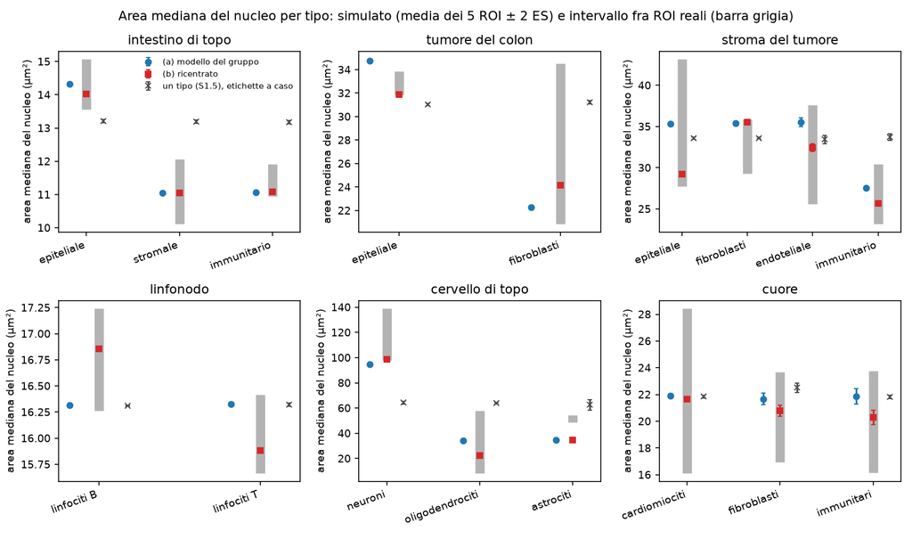

Area mediana del nucleo per tipo: tre bracci contro l’intervallo fra ROI reali.

Cosa guardare: i quadrati rossi (braccio ricentrato) stanno nelle barre grigie in quasi tutti i tipi; le croci (un tipo, etichette a caso) no nell’intestino, nel tumore e nel cervello; gli astrociti restano sotto in entrambi i bracci per tipo.

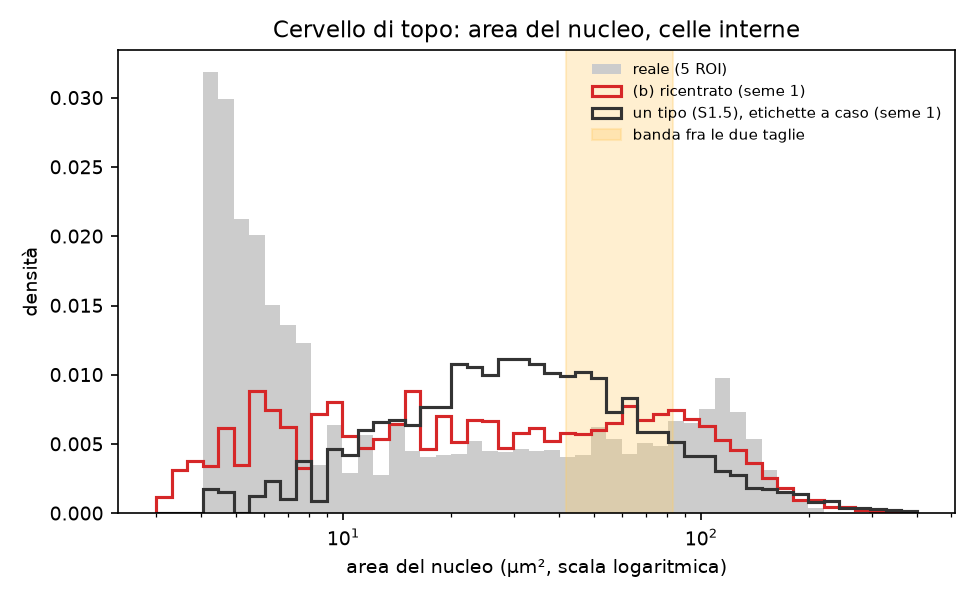

Cervello di topo: area del nucleo delle celle interne, reale contro simulato.

Cosa guardare: il simulato ha le due taglie ma riempie la banda fra le due; nel reale il picco a 4-8 µm² sono gli oggetti minuscoli di PH-2.

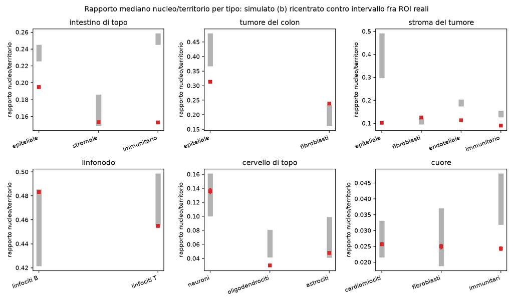

Rapporto mediano nucleo/territorio per tipo, braccio ricentrato.

Cosa guardare: nei tessuti dove i tipi veri hanno territori diversi (intestino, tumore, stroma) il simulato sta fuori dalle barre: lo spazio attorno al nucleo dipende dalla semina, non dal modello di taglia.

# Controprova

# Dopo il risultato: scelte, deviazioni, post hoc e revisione avversariale

Sezione aggiunta dopo i verdetti. Non cambia previsioni, intervalli o regole. I numeri si rileggono da `results/S1.5b/S1.5b_verdicts.csv` (banco v2), da `S1.5b_arm_rule.csv` e dai file citati riga per riga.

## Cancelli

[output not shown]

## Regola del braccio (scelta 2)

Nel banco v2 P-2 finisce in pareggio: 14 tipi confermati su 17 in entrambi i bracci. Decide P-1: il braccio ricentrato conferma 6 tessuti su 6, quello del gruppo 5, perché lo stroma è a cavallo dell’estremo alto (33.74 + 2 · 0.050 contro 33.79). **Vince il braccio ricentrato.** Il pareggio era annunciato come probabile e l’esito è fragile. Nel braccio ricentrato i fibroblasti dello stroma sono confermati con un margine di 0.15 errori standard (35.559 ± 2 · 0.134 contro 35.846, dalla tabella dei verdetti). Nel banco v1, con la semina per tipo in sequenza, il ricentrato vinceva già su P-2, 15 contro 11. Nel controfattuale indipendente del revisore del codice vinceva 14 contro 13. Nel merito il braccio ricentrato fa quello per cui era stato pensato: l’epitelio del tumore del colon è a 31.87 µm² contro 34.78 del braccio del gruppo (intervallo reale 31.84-33.86), i neuroni a 98.4 contro 94.8 (97.9-138.8). Decisione tecnica registrata in Tipi nei preset: braccio ricentrato, semina cieca al tipo, tipi predefiniti (DEC-019).

## Verdetti (braccio vincente, banco v2)

[output not shown]

## Scelte, deviazioni e correzioni dichiarate

- **D-1, area di riferimento della calibrazione** (trovata da G-4 prima del banco). Lo strumento Python usava la densità del modello non arrotondata (10 591.011…), il pacchetto quella a un decimale (10 591.0): scarto di 1e-7 sui rho dei gruppi. Lo strumento ora usa i valori del pacchetto e le righe B-186…B-208 sono state rigenerate prima del banco. A 6 cifre non cambia nulla, salvo l’ultima cifra di qualche rho.
- **D-2, composizione del cervello** (DEC-017). Il controllo del trasferimento è passato come scritto (accuratezza 0.916 sui 227 nuclei trovati nelle finestre di Luca; 0.967 su quelle di Federica). La quota di neuroni del preset passa da 0.652 a 0.700. Due limiti, emersi nel post hoc e nella revisione:
  - il trasferimento chiama «neuroni» una parte della glia vicina ai neuroni (glia trovata 31 su 50 nelle finestre di Luca; il neurone mai sbagliato). Correggendo con la matrice di confusione (PH-1) la quota sarebbe 0.664;
  - la replica di Federica non concorda: nelle sue finestre i nuclei persi sono soprattutto vascolari. Con i due valutatori insieme la quota sarebbe circa 0.61. Tutti i valori (0.61-0.70) stanno dentro la variabilità fra le aree vere: quota di neuroni da 0.53 a 0.76 fra le 5 ROI (`results/R6/R6_refs_roi_type_ph1.csv`). Nessuna previsione dipende dalla quota: si tiene la regola com’era scritta e il limite è spiegato. Lo scarto di accuratezza dovuto al nucleo appaiato fra i propri vicini è piccolo (0.916 → 0.907, revisione RC-09).
- **D-3, semina cieca al tipo (correzione dopo la revisione, RC-01).** La pre-registrazione diceva «nessun cambiamento della catena» e che la semina non usa la densità del tipo. Il codice v1 però seminava i tipi uno dopo l’altro, e con la distanza minima comune il tipo seminato per ultimo riceveva territori più piccoli. Nel linfonodo i mieloidi avevano territori più piccoli del 10 %. Nel test T12 il tipo seminato per ultimo è a 0.924 con la semina in sequenza e a 0.997 con quella cieca. È un errore dello strumento, contrario alla definizione scritta. La correzione è `seed_centroids(type_order = "blind")`: una sola semina per regione, con le etichette dei tipi permutate dopo, a conteggi invariati. `place_cells()` la usa con i preset per tipo. Il banco è stato rifatto (v2, 900 unità) con la stessa analisi pre-registrata; i risultati v1 restano in `results/S1.5b/_v1_before_review/`. Cambiano 6 verdetti:
  - braccio del gruppo, P-2: linfociti B e T da smentita a confermata, immunitario dell’intestino da indeterminata a confermata;
  - braccio del gruppo, P-7: fibroblasti dello stroma da indeterminata a smentita;
  - braccio ricentrato, P-7: linfociti B da smentita a confermata;
  - braccio ricentrato, P-2: neuroni da confermata a indeterminata. Il vincitore della regola non cambia. Le unità v2 sono state generate al commit `858dd1c`; il cambio dei predefiniti del commit successivo non le altera (92/92 md5 rigenerati dal revisore).
- **D-4, predefiniti.** Come pre-registrato, `types = "multi"` e `size_arm = "recentred"` sono ora i predefiniti di `tissue_preset_spec()` e `place_cells()` (test T5b). Gli script di S1.5 caricano `tools/S1.5_single_preset.R`, che chiede il preset a un tipo e riproduce S1.5 (md5 12/12 per il revisore, 300/300 nel banco). È un involucro fragile se uno script ricarica `R/04b*.R` dopo di esso (BL-155).
- **D-5, G-3 più ampio del pre-registrato.** Il braccio a un tipo è confrontato con S1.5 su tutte le 300 unità, non su 6.
- **D-6, mutanti** (RC-06). M2 è realizzato come «frazioni scalate di 0.9» e non come «non risolti inclusi»; M5 come «qualifica normale» e non come «epitelio non unito». Entrambi sono rilevati. M8 (semina cieca spenta) è stato aggiunto con la correzione D-3.
- **D-7, attesi** (RC-11). Le stime a mano del file sono state scritte prima di D-1 e della composizione corretta del cervello. Per il cervello l’atteso di P-1 passa da 78 a 80.6-82.6 µm² (`S1.5b_expected_roi.csv`). I verdetti non dipendono dagli attesi.
- **D-8, dettagli di analisi** (RV-2, RV-3, RV-4, RC-12): le frazioni sono tagliate a [0, 1] come in S1.5; l’estremo alto di P-5 è scritto 0.0287 (massimo reale 0.028734); la glia del riferimento è fatta dei soli nuclei con un tipo del gruppo della glia. Nessuno dei tre punti cambia un verdetto.
- **D-9, regola dei tipi minori** (RV-1, RC-13). Un tipo minore si confronta con la mediana dei soli tipi principali, come scritto. Lo strumento v1 aggiornava la mediana a ogni minore aggiunto. I gruppi sono identici, cambia solo la traccia.
- **D-10, interruzione termica.** Il banco v1 è stato fermato a 197 unità e ripreso con 3 worker (CPU a 93 °C con MMM in corsa). Le unità sono rilanciabili e nessuna è andata perduta.

## Analisi post hoc (dopo i verdetti)

- **PH-1, nuclei persi del cervello corretti per l’errore del trasferimento** (`tools/S1.5b_posthoc.py`, `S1.5b_posthoc_a5.csv`). Fra i persi la quota di neuroni passa da 0.855 a 0.701 (Luca); per Federica è 0.136, con i due valutatori insieme 0.457. Composizione del preset con la correzione: 0.664 di neuroni (vedi D-2).
- **PH-2, oggetti minuscoli nel cervello** (`S1.5b_posthoc_a5_small.csv`). Il 7.8 % dei nuclei di riferimento del cervello ha area sotto 8 µm²; il filtro delle maschere è 4 µm². Stanno soprattutto nella ROI r1 (22.6 %), che contiene una banda di sostanza bianca (figura 4), e sono etichettati quasi tutti come oligodendrociti (34.6 % degli oligodendrociti). Senza questi oggetti la dispersione del modello della glia scende da 0.87 a 0.71 e il massimo reale della banda sale a 0.261. Il simulato (0.290) resta fuori. Le finestre contate a mano non coprono la sostanza bianca (1 solo oggetto sotto 8 µm² su 253), quindi non sappiamo se siano nuclei veri o frammenti (BL-154).
- **PH-3, perché neuroni ed epitelio del tumore stanno al bordo basso.** Il modello di taglia lognormale riproduce la media geometrica dei nuclei veri, non la mediana. Nei neuroni il logaritmo dell’area è asimmetrico: mediana 111.6 µm², media geometrica 99.4, simulato 98.4. Nell’epitelio del tumore mediana e media geometrica coincidono (32.6) e il simulato sta il 2 % sotto (31.9), al bordo dell’intervallo. Non tocca nessuna conclusione.
- **D-desc-1, distanza dal vicino più vicino** (`S1.5b_desc_nn.csv`, media dei ROI, reale contro simulato):
  - neuroni 16.6 contro 14.7 µm;
  - immunitarie del cuore 8.8 contro 14.5;
  - fibroblasti del cuore 11.7 contro 14.6;
  - epitelio dello stroma 6.5 contro 8.9;
  - fibroblasti del tumore 7.2 contro 5.8. I tipi veri sono raggruppati o distanziati in modo specifico; la semina unica non lo riproduce (BL-153).
- **D-desc-2, tempi** (`S1.5b_desc_time.csv`): mediana per unità uguale entro 0.5 s fra i bracci per tipo e quello a un tipo (per esempio 28.7 contro 29.0 s nell’intestino).
- **D-desc-3** (figura 4): con la semina unica i tipi sono mescolati in modo uniforme dentro la regione, mentre nei tessuti veri l’epitelio forma ghiandole e villi.

## Revisione avversariale

Due revisori indipendenti, in sola lettura sul repo e con codice proprio (uscite in `/mnt/micron/geo_spatialtrans/S1.5b/review_recalc` e `review_code`, sottocartelle `v2`).

- **Ricalcolo, primo giro** (commit `6efa1c2`): 3 781/3 788 confronti identici. I 7 diversi stanno nella traccia della regola dei gruppi (RV-1, corretta). I gruppi, i riferimenti reali (186 righe), la calibrazione, la composizione del cervello, 18 unità rigenerate (md5 18/18), i 165 verdetti, CP-1 e G-3 coincidono.
- **Codice, primo giro**: 16 rilievi, fra cui un bug che cambia verdetti (RC-01, semina in sequenza, corretto: D-3) e un bug del runner che non cambia nulla (RC-02, corretto). Seguono:
  - test che dipendevano dall’implementazione (RC-03, RC-04, RC-07): aggiunti T6c su BIO_REFERENCES, T6d, T6e, T6f, T11, T12;
  - deviazioni non dichiarate (RC-05, RC-06, RC-11, ora D-4, D-6, D-7);
  - limiti della composizione del cervello con i nuclei persi tipizzati (DEC-017) (RC-08…RC-10, ora D-2);
  - rilievi minori: RC-12…RC-16 (D-8, D-9, BL-155, BL-156; RC-16: le maschere di tessuto di R2 sono fuori da git, voce già nota).
- **Secondo giro** (commit `946df1d`):
  - ricalcolo: 3 583/3 583 identici; 92 unità rigenerate con md5 identico; il territorio non dipende più dal tipo (mieloidi del linfonodo 1.001, con il codice v1 0.908);
  - codice: nessun bug nuovo; mutanti del primo giro 17/17; rilievi V2-03 e V2-04 coperti da T6e e T6f, V2-09 corretto, V2-08 e V2-11 in BL-155.

# Cosa è girato

- Banco v2: 900 unità (30 ROI × 10 semi × 3 bracci), seme = 20261021 + 1000 · i + s come S1.5, generato al commit `858dd1c` su lesexp-server con 16 worker a un thread in 17.2 minuti; banco v1 (prima della correzione della semina) al commit `fe432e8`, 81.9 minuti con 3-6 worker, conservato in `results/S1.5b/_v1_before_review/`.
- md5 dei 101 file reali letti: identici prima e dopo (`S1.5b_md5_before.csv`, `S1.5b_md5_after.csv`).
- Tempi per unità (mediana, secondi):

Tempo di place_cells() per unità (mediana, s)

| archetype | group | recentred | single |
| --- | --- | --- | --- |
| A1 | 29.2 | 28.7 | 29.0 |
| A2 | 16.8 | 16.7 | 16.7 |
| A3 | 3.1 | 3.0 | 3.1 |
| A4 | 27.5 | 27.8 | 27.6 |
| A5 | 15.9 | 15.9 | 15.9 |
| A6 | 7.4 | 7.4 | 7.4 |

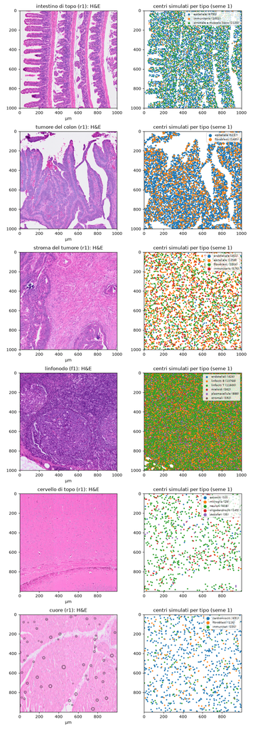

Un’area per tessuto: H&E e centri simulati per tipo (braccio ricentrato, seme 1).

# Appendice

## Gruppi di taglia e modelli per tipo

Righe B-186…B-208: composizione, gruppo di taglia, modello del gruppo, territorio reale del tipo, densità del tipo puro, rho del catalogo

| tessuto | tipo | gruppo | frazione | rho | beta | sigma | m_t | densità_tipo | rho_ricentrato |
| --- | --- | --- | --- | --- | --- | --- | --- | --- | --- |
| intestino di topo | epiteliale | 1 | 0.685 | 0.3987 | 0.1591 | 0.4590 | 63.5 | 12254 | 0.4192 |
| intestino di topo | immunitario | 2 | 0.101 | 0.3419 | -0.0034 | 0.4605 | 45.8 | 16984 | 0.4336 |
| intestino di topo | stromale e muscolo liscio | 2 | 0.214 | 0.3419 | -0.0034 | 0.4605 | 67.9 | 11460 | 0.3557 |
| tumore del colon | epiteliale | 1 | 0.776 | 0.5450 | 0.4064 | 0.5043 | 83.0 | 10122 | 0.5651 |
| tumore del colon | fibroblasti | 2 | 0.224 | 0.4316 | 0.3221 | 0.5100 | 132.9 | 6324 | 0.4202 |
| stroma del tumore | endoteliale | 1 | 0.081 | 0.3832 | 0.1570 | 0.5496 | 164.5 | 3427 | 0.3334 |
| stroma del tumore | epiteliale | 1 | 0.407 | 0.3832 | 0.1570 | 0.5496 | 87.4 | 6448 | 0.4142 |
| stroma del tumore | fibroblasti | 1 | 0.325 | 0.3832 | 0.1570 | 0.5496 | 301.8 | 1868 | 0.2708 |
| stroma del tumore | immunitario | 2 | 0.186 | 0.3386 | 0.1604 | 0.5181 | 186.5 | 3022 | 0.2822 |
| linfonodo | endoteliali | 1 | 0.015 | 0.6790 | 0.4550 | 0.2100 | 32.3 | 30701 | 0.6849 |
| linfonodo | linfociti B | 1 | 0.495 | 0.6790 | 0.4550 | 0.2100 | 37.4 | 26475 | 0.6804 |
| linfonodo | linfociti T | 1 | 0.417 | 0.6790 | 0.4550 | 0.2100 | 32.8 | 30239 | 0.6845 |
| linfonodo | mieloidi | 1 | 0.020 | 0.6790 | 0.4550 | 0.2100 | 39.7 | 24957 | 0.6786 |
| linfonodo | plasmacellule | 1 | 0.032 | 0.6790 | 0.4550 | 0.2100 | 34.5 | 28734 | 0.6829 |
| linfonodo | stromali | 1 | 0.021 | 0.6790 | 0.4550 | 0.2100 | 33.1 | 29934 | 0.6842 |
| cervello di topo | astrociti | 1 | 0.061 | 0.2000 | 0.5886 | 0.8673 | 740.3 | 1299 | 0.2088 |
| cervello di topo | microglia | 1 | 0.031 | 0.2000 | 0.5886 | 0.8673 | 1099.8 | 874 | 0.2163 |
| cervello di topo | oligodendrociti | 1 | 0.168 | 0.2000 | 0.5886 | 0.8673 | 370.6 | 2594 | 0.1964 |
| cervello di topo | vascolari | 1 | 0.040 | 0.2000 | 0.5886 | 0.8673 | 1016.3 | 946 | 0.2147 |
| cervello di topo | neuroni | 2 | 0.700 | 0.3245 | 0.2050 | 0.4785 | 899.3 | 1069 | 0.3345 |
| cuore | cardiomiociti | 1 | 0.758 | 0.1540 | 0.1220 | 0.4900 | 790.5 | 914 | 0.1433 |
| cuore | fibroblasti | 1 | 0.128 | 0.1540 | 0.1220 | 0.4900 | 618.3 | 1169 | 0.1573 |
| cuore | immunitari | 1 | 0.115 | 0.1540 | 0.1220 | 0.4900 | 469.1 | 1541 | 0.1746 |

Traccia della regola dei gruppi di taglia

| archetype | step | kind | a | b | ratio | margin | accepted |
| --- | --- | --- | --- | --- | --- | --- | --- |
| A1 | 1 | merge_main | immunitario | stromale e muscolo liscio | 1.0000000 | 1.095 | True |
| A1 | 2 | merge_main | epiteliale | immunitario\|stromale e muscolo liscio | 1.2400000 | 1.095 | False |
| A2 | 1 | merge_main | epiteliale | fibroblasti | 1.3353846 | 1.161 | False |
| A3 | 1 | merge_main | epiteliale | fibroblasti | 1.0140515 | 1.216 | True |
| A3 | 2 | merge_main | endoteliale | epiteliale\|fibroblasti | 1.0408654 | 1.216 | True |
| A3 | 3 | merge_main | endoteliale\|epiteliale\|fibroblasti | immunitario | 1.2336182 | 1.216 | False |
| A4 | 1 | merge_main | linfociti B | linfociti T | 1.0467290 | 1.062 | True |
| A4 | 2 | assign_minor | endoteliali | linfociti B\|linfociti T | 0.9223744 | 1.062 | True |
| A4 | 3 | assign_minor | mieloidi | linfociti B\|linfociti T | 1.0365297 | 1.062 | True |
| A4 | 4 | assign_minor | plasmacellule | linfociti B\|linfociti T | 0.9543379 | 1.062 | True |
| A4 | 5 | assign_minor | stromali | linfociti B\|linfociti T | 0.9589041 | 1.062 | True |
| A5 | 1 | merge_main | astrociti | oligodendrociti | 1.6140777 | 2.096 | True |
| A5 | 2 | merge_main | astrociti\|oligodendrociti | neuroni | 3.5825243 | 2.096 | False |
| A5 | 3 | assign_minor | microglia | astrociti\|oligodendrociti | 0.6513570 | 2.096 | True |
| A5 | 4 | assign_minor | vascolari | astrociti\|oligodendrociti | 0.6503132 | 2.096 | True |
| A6 | 1 | merge_main | cardiomiociti | fibroblasti | 1.0114068 | 1.808 | True |
| A6 | 2 | merge_main | cardiomiociti\|fibroblasti | immunitari | 1.1129707 | 1.808 | True |

## Distanza dal vicino più vicino per tipo

Mediana della distanza dal vicino più vicino (µm), media dei ROI

| archetype | cell_type | nn_median.reale | nn_median.recentred | nn_median.single |
| --- | --- | --- | --- | --- |
| A5 | astrociti | 15.62 | 14.68 | 16.12 |
| A6 | cardiomiociti | 15.12 | 15.03 | 15.03 |
| A3 | endoteliale | 7.62 | 8.73 | 8.91 |
| A1 | epiteliale | 4.59 | 4.68 | 4.66 |
| A2 | epiteliale | 6.02 | 5.78 | 5.80 |
| A3 | epiteliale | 6.49 | 8.92 | 8.94 |
| A2 | fibroblasti | 7.22 | 5.77 | 5.71 |
| A3 | fibroblasti | 9.85 | 8.93 | 8.80 |
| A6 | fibroblasti | 11.68 | 14.55 | 14.71 |
| A6 | immunitari | 8.83 | 14.54 | 14.21 |
| A1 | immunitario | 4.38 | 4.64 | 4.75 |
| A3 | immunitario | 7.91 | 8.74 | 8.83 |
| A4 | linfociti B | 4.77 | 4.52 | 4.52 |
| A4 | linfociti T | 4.64 | 4.52 | 4.52 |
| A5 | neuroni | 16.62 | 14.69 | 14.47 |
| A5 | oligodendrociti | 13.73 | 14.63 | 14.78 |
| A1 | stromale e muscolo liscio | 5.06 | 4.67 | 4.68 |

## Composizione del cervello (DEC-017) e post hoc

Nuclei persi da Cellpose tipizzati dall’espressione

| rater | cell_type | n_points | n_missed | n_missed_typed | n_matched_eval | accuracy_matched | q | fraction_r6 | fraction_missed | fraction_corrected | passes |
| --- | --- | --- | --- | --- | --- | --- | --- | --- | --- | --- | --- |
| Federica | astrociti | 148 | 27 | 27 | 121 | 0.967 | 0.182 | 0.066 | 0.000 | 0.054 | True |
| Federica | microglia | 148 | 27 | 27 | 121 | 0.967 | 0.182 | 0.036 | 0.074 | 0.043 | True |
| Federica | oligodendrociti | 148 | 27 | 27 | 121 | 0.967 | 0.182 | 0.198 | 0.037 | 0.168 | True |
| Federica | vascolari | 148 | 27 | 27 | 121 | 0.967 | 0.182 | 0.047 | 0.370 | 0.106 | True |
| Federica | neuroni | 148 | 27 | 27 | 121 | 0.967 | 0.182 | 0.652 | 0.519 | 0.628 | True |
| Luca | astrociti | 296 | 69 | 69 | 227 | 0.916 | 0.233 | 0.066 | 0.043 | 0.061 | True |
| Luca | microglia | 296 | 69 | 69 | 227 | 0.916 | 0.233 | 0.036 | 0.014 | 0.031 | True |
| Luca | oligodendrociti | 296 | 69 | 69 | 227 | 0.916 | 0.233 | 0.198 | 0.072 | 0.168 | True |
| Luca | vascolari | 296 | 69 | 69 | 227 | 0.916 | 0.233 | 0.047 | 0.014 | 0.040 | True |
| Luca | neuroni | 296 | 69 | 69 | 227 | 0.916 | 0.233 | 0.652 | 0.855 | 0.700 | True |

PH-1: quota dei persi corretta per l’errore del trasferimento

| rater | cell_type | n_missed | observed_share | corrected_share | recall_matched | n_matched_true | composition_if_corrected |
| --- | --- | --- | --- | --- | --- | --- | --- |
| Luca | neuroni | 69 | 0.855 | 0.701 | 1.000 | 177 | 0.664 |
| Luca | astrociti | 69 | 0.043 | 0.046 | 0.947 | 19 | 0.062 |
| Luca | oligodendrociti | 69 | 0.072 | 0.137 | 0.529 | 17 | 0.183 |
| Luca | microglia | 69 | 0.014 | 0.043 | 0.333 | 9 | 0.038 |
| Luca | vascolari | 69 | 0.014 | 0.072 | 0.200 | 5 | 0.053 |
| Federica | neuroni | 27 | 0.519 | 0.136 | 1.000 | 98 | NA |
| Federica | astrociti | 27 | 0.000 | 0.000 | 1.000 | 8 | NA |
| Federica | oligodendrociti | 27 | 0.037 | 0.049 | 0.750 | 8 | NA |
| Federica | microglia | 27 | 0.074 | 0.074 | 1.000 | 3 | NA |
| Federica | vascolari | 27 | 0.370 | 0.741 | 0.500 | 4 | NA |
| both | neuroni | 96 | 0.760 | 0.457 | 1.000 | 275 | NA |
| both | astrociti | 96 | 0.031 | 0.032 | 0.963 | 27 | NA |
| both | oligodendrociti | 96 | 0.062 | 0.104 | 0.600 | 25 | NA |
| both | microglia | 96 | 0.031 | 0.062 | 0.500 | 12 | NA |
| both | vascolari | 96 | 0.115 | 0.344 | 0.333 | 9 | NA |

PH-2: oggetti di area < 8 µm² nel cervello

| set | n_glia | rho_glia | beta_glia | sigma_glia | band_min | band_max | frac_small_r1 | frac_small_oligo |
| --- | --- | --- | --- | --- | --- | --- | --- | --- |
| tutti | 651 | 0.200 | 0.589 | 0.867 | 0.167 | 0.236 | 0.226 | 0.346 |
| senza a_n < 8 | 506 | 0.215 | 0.254 | 0.712 | 0.167 | 0.261 | 0.226 | 0.346 |

## Da dove vengono i numeri del riassunto

[output not shown]